#Define the Question Enterprenuer with an online Crypocurrency course wants to advertise her course on the blog.Find out which audience is likely to click the link.

#Context The enterprenuer wants to get the target audience who will click on his /her advertisment for the crypocurrency course she wants to put on the blog.

#metric of success To do exploratory data analysis to get insights that help the advertising business emerge.

```r
#Library installation

install.packages("dplyr")
library(dplyr) # data manipulation
#Load the dataset we are working on

ads <- read.csv("advertising.csv")
ads
```

[output not shown]

[output cut: 4990 more lines]

```r
#checking the first six rows
head(ads)
```

```
##   Daily.Time.Spent.on.Site Age Area.Income Daily.Internet.Usage
## 1                    68.95  35    61833.90               256.09
## 2                    80.23  31    68441.85               193.77
## 3                    69.47  26    59785.94               236.50
## 4                    74.15  29    54806.18               245.89
## 5                    68.37  35    73889.99               225.58
## 6                    59.99  23    59761.56               226.74
##                           Ad.Topic.Line           City Male    Country
## 1    Cloned 5thgeneration orchestration    Wrightburgh    0    Tunisia
## 2    Monitored national standardization      West Jodi    1      Nauru
## 3      Organic bottom-line service-desk       Davidton    0 San Marino
## 4 Triple-buffered reciprocal time-frame West Terrifurt    1      Italy
## 5         Robust logistical utilization   South Manuel    0    Iceland
## 6       Sharable client-driven software      Jamieberg    1     Norway
##             Timestamp Clicked.on.Ad
## 1 2016-03-27 00:53:11             0
## 2 2016-04-04 01:39:02             0
## 3 2016-03-13 20:35:42             0
## 4 2016-01-10 02:31:19             0
## 5 2016-06-03 03:36:18             0
## 6 2016-05-19 14:30:17             0
```

```r
#checking the datatypes
str(ads)
```

```
## 'data.frame':    1000 obs. of  10 variables:
##  $ Daily.Time.Spent.on.Site: num  69 80.2 69.5 74.2 68.4 ...
##  $ Age                     : int  35 31 26 29 35 23 33 48 30 20 ...
##  $ Area.Income             : num  61834 68442 59786 54806 73890 ...
##  $ Daily.Internet.Usage    : num  256 194 236 246 226 ...
##  $ Ad.Topic.Line           : Factor w/ 1000 levels "Adaptive 24hour Graphic Interface",..: 92 465 567 904 767 806 223 724 108 455 ...
##  $ City                    : Factor w/ 969 levels "Adamsbury","Adamside",..: 962 904 112 940 806 283 47 672 885 713 ...
##  $ Male                    : int  0 1 0 1 0 1 0 1 1 1 ...
##  $ Country                 : Factor w/ 237 levels "Afghanistan",..: 216 148 185 104 97 159 146 13 83 79 ...
##  $ Timestamp               : Factor w/ 1000 levels "2016-01-01 02:52:10",..: 440 475 368 57 768 690 131 334 549 942 ...
##  $ Clicked.on.Ad           : int  0 0 0 0 0 0 0 1 0 0 ...
```

```r
#checking for number of columns and rows
colnames(ads)
```

```
##  [1] "Daily.Time.Spent.on.Site" "Age"
##  [3] "Area.Income"              "Daily.Internet.Usage"
##  [5] "Ad.Topic.Line"            "City"
##  [7] "Male"                     "Country"
##  [9] "Timestamp"                "Clicked.on.Ad"
```

```r
#summary of dataframe
summary(ads)
```

```
##  Daily.Time.Spent.on.Site      Age         Area.Income    Daily.Internet.Usage
##  Min.   :32.60            Min.   :19.00   Min.   :13996   Min.   :104.8
##  1st Qu.:51.36            1st Qu.:29.00   1st Qu.:47032   1st Qu.:138.8
##  Median :68.22            Median :35.00   Median :57012   Median :183.1
##  Mean   :65.00            Mean   :36.01   Mean   :55000   Mean   :180.0
##  3rd Qu.:78.55            3rd Qu.:42.00   3rd Qu.:65471   3rd Qu.:218.8
##  Max.   :91.43            Max.   :61.00   Max.   :79485   Max.   :270.0
##
##                                  Ad.Topic.Line              City
##  Adaptive 24hour Graphic Interface      :  1   Lisamouth      :  3
##  Adaptive asynchronous attitude         :  1   Williamsport   :  3
##  Adaptive context-sensitive application :  1   Benjaminchester:  2
##  Adaptive contextually-based methodology:  1   East John      :  2
##  Adaptive demand-driven knowledgebase   :  1   East Timothy   :  2
##  Adaptive uniform capability            :  1   Johnstad       :  2
##  (Other)                                :994   (Other)        :986
##       Male                 Country                  Timestamp   Clicked.on.Ad
##  Min.   :0.000   Czech Republic:  9   2016-01-01 02:52:10:  1   Min.   :0.0
##  1st Qu.:0.000   France        :  9   2016-01-01 03:35:35:  1   1st Qu.:0.0
##  Median :0.000   Afghanistan   :  8   2016-01-01 05:31:22:  1   Median :0.5
##  Mean   :0.481   Australia     :  8   2016-01-01 08:27:06:  1   Mean   :0.5
##  3rd Qu.:1.000   Cyprus        :  8   2016-01-01 15:14:24:  1   3rd Qu.:1.0
##  Max.   :1.000   Greece        :  8   2016-01-01 20:17:49:  1   Max.   :1.0
##                  (Other)       :950   (Other)            :994
```

```r
#check the shape of the dataset
dim(ads)
```

```
## [1] 1000   10
```

```r
#cleaning the Data now
is.na(ads)
```

[output not shown]

[output cut: 1987 more lines]

```r
colSums(is.na(ads))
```

```
## Daily.Time.Spent.on.Site                      Age              Area.Income
##                        0                        0                        0
##     Daily.Internet.Usage            Ad.Topic.Line                     City
##                        0                        0                        0
##                     Male                  Country                Timestamp
##                        0                        0                        0
##            Clicked.on.Ad
##                        0
```

```r
#in our dataset there are  no missing values
```

```r
#check for duplicated values
duplicated(ads)
```

[output not shown]

[output cut: 69 more lines]

```r
#no duplicated values
```

```r
#date time column separated
ads$Date <- sapply(strsplit(as.character(ads$Timestamp), " "), "[", 1)
ads$Time<- sapply(strsplit(as.character(ads$Timestamp), " "), "[", 2)
```

```r
head(ads)
```

```
##   Daily.Time.Spent.on.Site Age Area.Income Daily.Internet.Usage
## 1                    68.95  35    61833.90               256.09
## 2                    80.23  31    68441.85               193.77
## 3                    69.47  26    59785.94               236.50
## 4                    74.15  29    54806.18               245.89
## 5                    68.37  35    73889.99               225.58
## 6                    59.99  23    59761.56               226.74
##                           Ad.Topic.Line           City Male    Country
## 1    Cloned 5thgeneration orchestration    Wrightburgh    0    Tunisia
## 2    Monitored national standardization      West Jodi    1      Nauru
## 3      Organic bottom-line service-desk       Davidton    0 San Marino
## 4 Triple-buffered reciprocal time-frame West Terrifurt    1      Italy
## 5         Robust logistical utilization   South Manuel    0    Iceland
## 6       Sharable client-driven software      Jamieberg    1     Norway
##             Timestamp Clicked.on.Ad       Date     Time
## 1 2016-03-27 00:53:11             0 2016-03-27 00:53:11
## 2 2016-04-04 01:39:02             0 2016-04-04 01:39:02
## 3 2016-03-13 20:35:42             0 2016-03-13 20:35:42
## 4 2016-01-10 02:31:19             0 2016-01-10 02:31:19
## 5 2016-06-03 03:36:18             0 2016-06-03 03:36:18
## 6 2016-05-19 14:30:17             0 2016-05-19 14:30:17
```

```r
#here we change the male column to gender where 1 is male and 0 female
names(ads)[names(ads) == "Male"] <- "Gender"
names
```

```
## function (x)  .Primitive("names")
```

```r
head(ads)
```

```
##   Daily.Time.Spent.on.Site Age Area.Income Daily.Internet.Usage
## 1                    68.95  35    61833.90               256.09
## 2                    80.23  31    68441.85               193.77
## 3                    69.47  26    59785.94               236.50
## 4                    74.15  29    54806.18               245.89
## 5                    68.37  35    73889.99               225.58
## 6                    59.99  23    59761.56               226.74
##                           Ad.Topic.Line           City Gender    Country
## 1    Cloned 5thgeneration orchestration    Wrightburgh      0    Tunisia
## 2    Monitored national standardization      West Jodi      1      Nauru
## 3      Organic bottom-line service-desk       Davidton      0 San Marino
## 4 Triple-buffered reciprocal time-frame West Terrifurt      1      Italy
## 5         Robust logistical utilization   South Manuel      0    Iceland
## 6       Sharable client-driven software      Jamieberg      1     Norway
##             Timestamp Clicked.on.Ad       Date     Time
## 1 2016-03-27 00:53:11             0 2016-03-27 00:53:11
## 2 2016-04-04 01:39:02             0 2016-04-04 01:39:02
## 3 2016-03-13 20:35:42             0 2016-03-13 20:35:42
## 4 2016-01-10 02:31:19             0 2016-01-10 02:31:19
## 5 2016-06-03 03:36:18             0 2016-06-03 03:36:18
## 6 2016-05-19 14:30:17             0 2016-05-19 14:30:17
```

```r
#convert Gender and  Clicked.on.Ad TO factor
list=c("Gender","Clicked.on.Ad")
for (f in list){
  ads[,f]=as.factor(ads[,f])
}
```

```r
#checking for outliers
install.packages('colorspace')
```

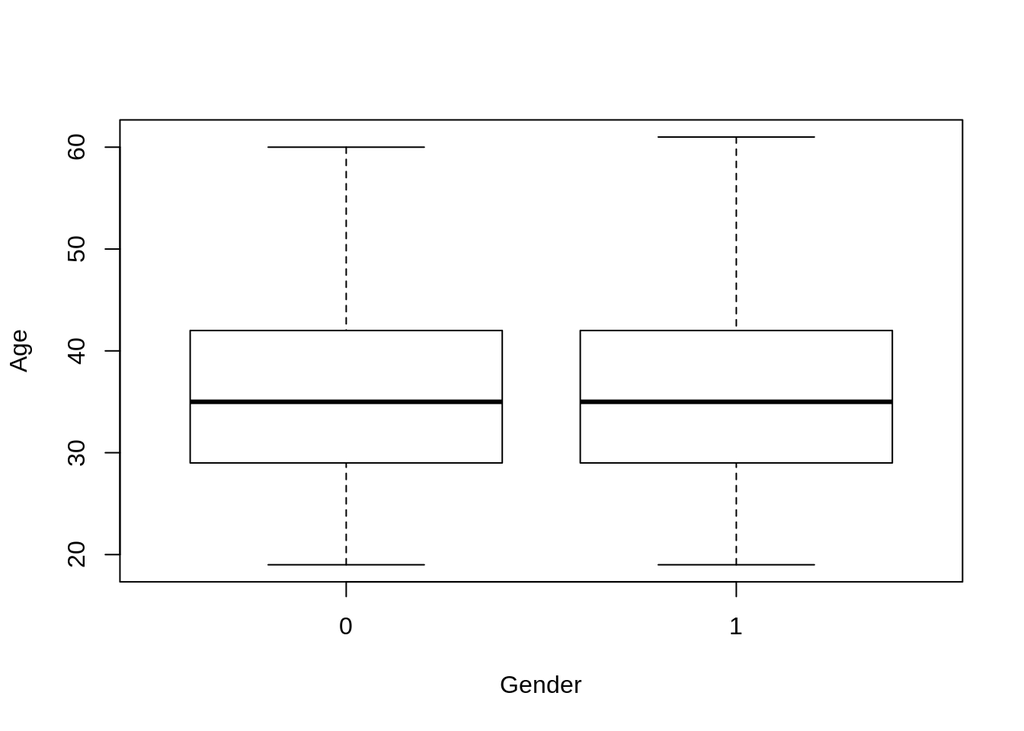

```r
install.packages("ggplot2")
library(ggplot2)
install.packages('Rmisc', dependencies = TRUE)
library(Rmisc)
#age and gender have no outlierss
boxplot(Age~Gender,data=ads)
```

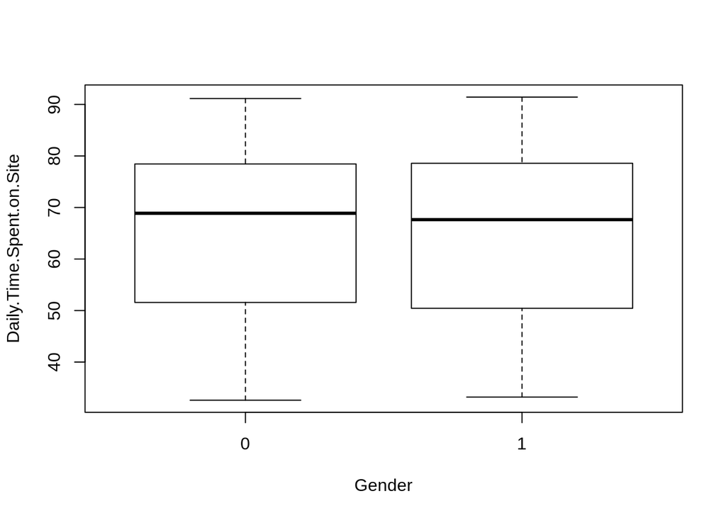

```r
#no outliers in Daily.Time.Spent.on.Site
boxplot(Daily.Time.Spent.on.Site~Gender,data=ads)
```

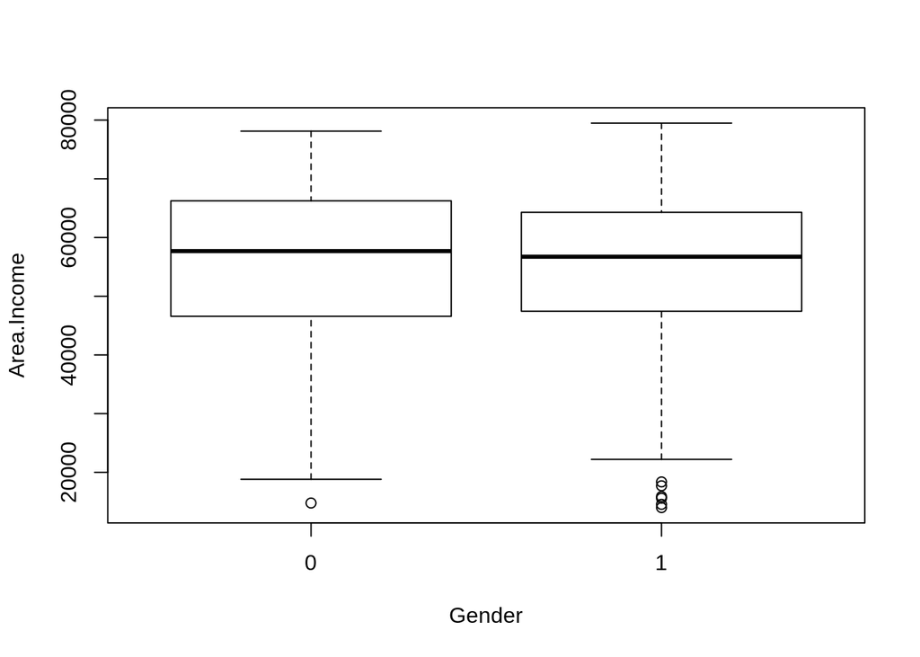

```r
#area of income contains outliers
boxplot(Area.Income~Gender,data=ads)
```

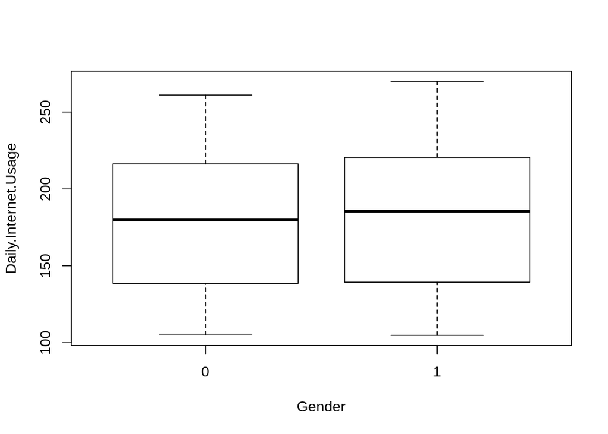

```r
#daily internet usage has no outliers
boxplot(Daily.Internet.Usage~Gender,data=ads)
```

```r
#remove the outliers on Area Income
#ads[!ads %in% boxplot.stats(ads)$out]
```

```r
install.packages("ggpubr")
library("ggpubr")
#check for correlation between Male and Daily.Time.Spent.on.Site
#res <- cor.test(ads$Gender, ads$Daily.Time.Spent.on.Site,
                    #method = "pearson")
#res
```

```r
#res <- cor.test(ads$Gender, ads$Area.Income,
                    #method = "pearson")
   #res
```

```r
#geneeral check for correlation in heatmap
library("ggpubr")
```

```r
library(RColorBrewer)
install.packages("corrplot")
library(corrplot)
#Subsetting the numerical variables to check correlations.
#
num_cols = subset(ads, select = c("Daily.Time.Spent.on.Site", "Age", "Area.Income", "Daily.Internet.Usage"))
num_cols
```

[output not shown]

[output cut: 986 more lines]

```r
cor(num_cols)
```

```
##                          Daily.Time.Spent.on.Site        Age Area.Income
## Daily.Time.Spent.on.Site                1.0000000 -0.3315133   0.3109544
## Age                                    -0.3315133  1.0000000  -0.1826050
## Area.Income                             0.3109544 -0.1826050   1.0000000
## Daily.Internet.Usage                    0.5186585 -0.3672086   0.3374955
##                          Daily.Internet.Usage
## Daily.Time.Spent.on.Site            0.5186585
## Age                                -0.3672086
## Area.Income                         0.3374955
## Daily.Internet.Usage                1.0000000
```

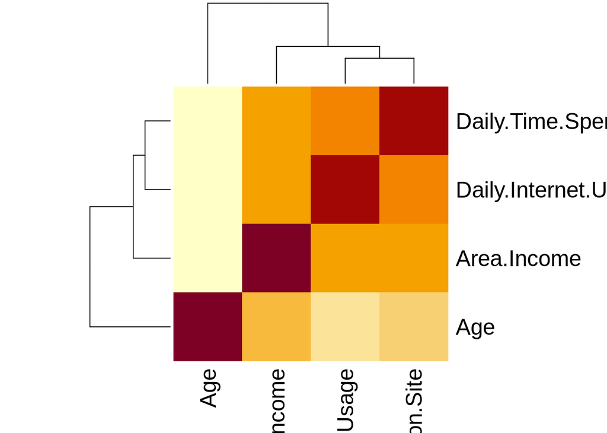

```r
# Plotting a heatmap for the correlations.
heatmap(cor(num_cols))
```